# NYC Flights Data

Mia Fitzgerald

4/16/2026

### First 6 Origin/Destination Pairs

```r
OD_flights <- flights %>%
  count(origin, dest)

OD_flights %>%
  head(6) %>%
  kable()
```

| origin | dest | n |
| --- | --- | --- |
| EWR | ALB | 439 |
| EWR | ANC | 8 |
| EWR | ATL | 5022 |
| EWR | AUS | 968 |
| EWR | AVL | 265 |
| EWR | BDL | 443 |

I summarized the massive flights dataset by using count(origin, dest) to tally every unique route and create a frequency column. To keep my report professional, I used head(6) and kable() to transform the raw data into a clean, readable table. [^1]

### XLOOKUP to Join Coordinates

```r
airports_3 <- airports %>%
  select(lat, lon, faa)

OD_flights2 <- OD_flights %>%
  left_join(airports_3, join_by(origin == faa)) %>%
  rename(origin_lat = lat, origin_lon = lon) %>%
  relocate(origin_lat, origin_lon, .before = dest)

OD_flights2 %>%
  head(6) %>%
  kable()
```

| origin | origin_lat | origin_lon | dest | n |
| --- | --- | --- | --- | --- |
| EWR | 40.6925 | -74.16867 | ALB | 439 |
| EWR | 40.6925 | -74.16867 | ANC | 8 |
| EWR | 40.6925 | -74.16867 | ATL | 5022 |
| EWR | 40.6925 | -74.16867 | AUS | 968 |
| EWR | 40.6925 | -74.16867 | AVL | 265 |
| EWR | 40.6925 | -74.16867 | BDL | 443 |

I refined the airports dataset to isolate only the essential coordinates and unique FAA codes for a more efficient merge. I then used left_join to physically “paste” these coordinates onto my flight data by matching them to the origin airport. After renaming and relocating the columns for better organization, I displayed the first six rows with kable(). [^2]

### First 6 Latitude and Longitude of the Destination Airports

```r
OD_flights3 <- OD_flights %>%
  left_join(airports_3, join_by(dest == faa)) %>%
  rename(dest_lat = lat, dest_lon = lon) %>%
  relocate(dest_lat, dest_lon, .before = n)

OD_flights3 %>%
  head(6) %>%
  kable()
```

| origin | dest | dest_lat | dest_lon | n |
| --- | --- | --- | --- | --- |
| EWR | ALB | 42.74827 | -73.80169 | 439 |
| EWR | ANC | 61.17436 | -149.99636 | 8 |
| EWR | ATL | 33.63672 | -84.42807 | 5022 |
| EWR | AUS | 30.19453 | -97.66989 | 968 |
| EWR | AVL | 35.43619 | -82.54181 | 265 |
| EWR | BDL | 41.93889 | -72.68322 | 443 |

I did the same thing but for the destination coordinates. [^3]

### Map of USA

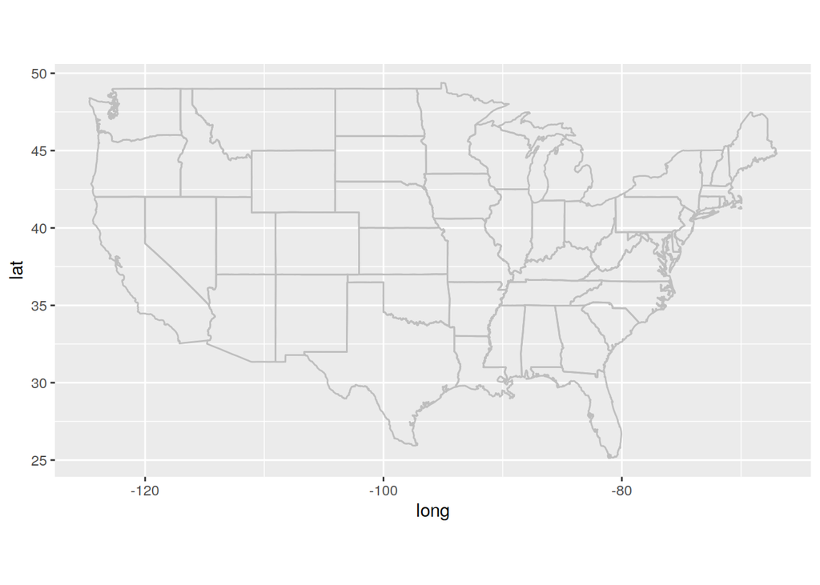

```r
ggplot() +
geom_polygon(data = map_data("state"), mapping = aes(x = long, y = lat, group = group), fill = NA, color = "gray") +
coord_fixed(1.3)
```

Imported the ggplot2 package to make a map with guidance code. [^4]

### The Flight Frequency Mapped from NYC

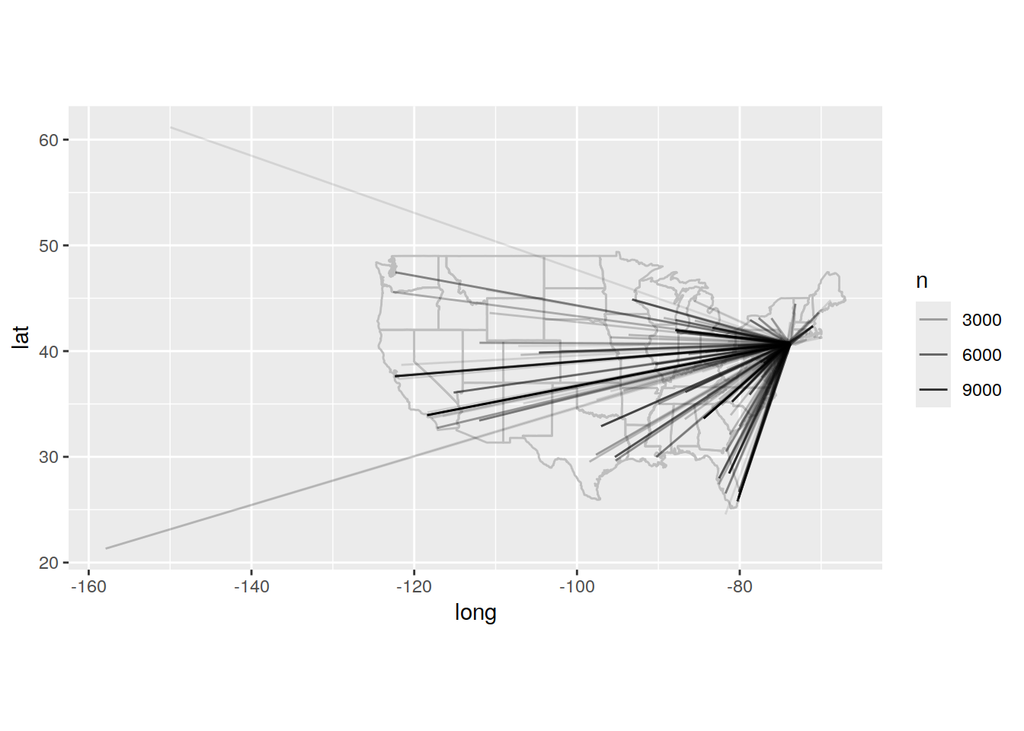

```r
OD_all_coords <- OD_flights3 %>%
  left_join(airports_3, join_by(origin == faa)) %>%
  rename(origin_lat = lat, origin_lon = lon) %>%
  relocate(origin_lat, origin_lon, .before = dest)

ggplot() +
geom_polygon(data = map_data("state"), mapping = aes(x = long, y = lat, group = group), fill = NA, color = "gray") +
coord_fixed(1.3) +
geom_segment(data = OD_all_coords, mapping = aes(x = origin_lon, y = origin_lat, xend = dest_lon, yend = dest_lat, alpha = n))
```

I combined the origin and destination coordinates into a single dataset, ensuring each route had a complete set of start and end points. I then use geom_segment to map the actual flight paths across the country. The plot uses the n variable for transparency, which effectively highlights the busiest travel routes. [^5]

### Filtering out Flights Outside the U.S.

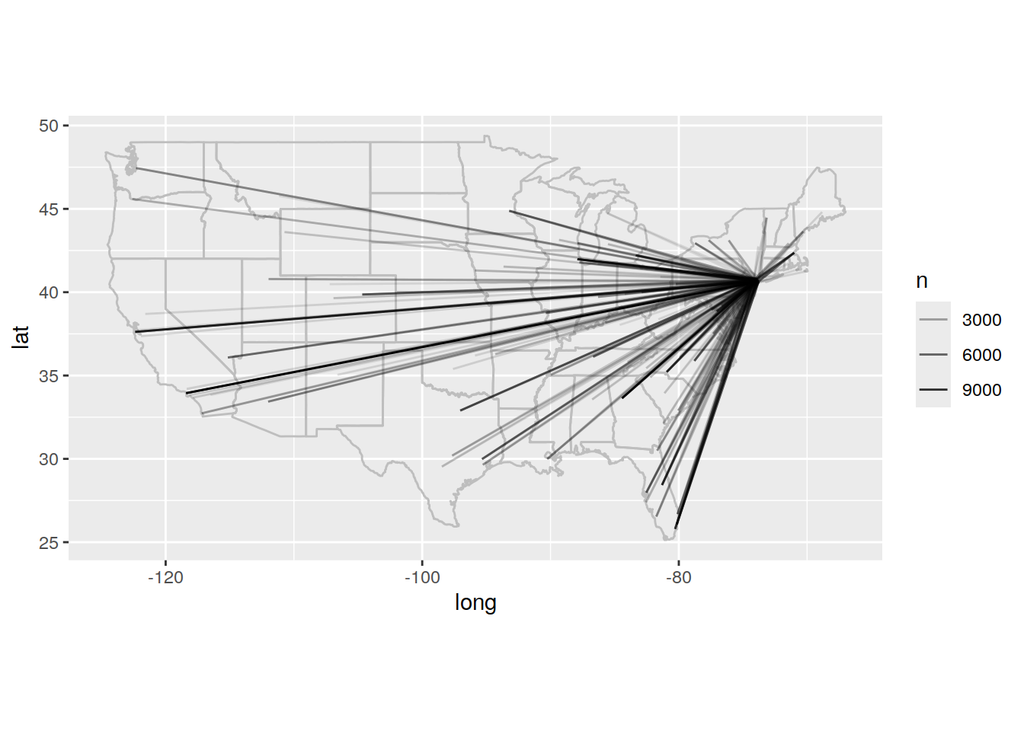

```r
OD_all_coords %>%
  filter(dest_lat > 25 & dest_lat < 50) %>%
ggplot() +
geom_polygon(data = map_data("state"), mapping = aes(x = long, y = lat, group = group), fill = NA, color = "gray") +
coord_fixed(1.3) +
geom_segment(mapping = aes(x = origin_lon, y = origin_lat, xend = dest_lon, yend = dest_lat, alpha = n))
```

I filtered the dataset to focus exclusively on the continental US, removing long-distance flights that distorted the map’s scale. [^6]

[^1]: Question 1 complete
[^2]: Question 2 complete
[^3]: Question 3 complete
[^4]: Question 4 complete
[^5]: Question 5 complete
[^6]: Question 6 complete